# 253-lp4

Timothy Paek

2025-04-07

# Preprocessing

This code is copy+pasted from lp3, though less arbitrarily verbose from print statements. Preparation for lp4 checks if the preprocessing was done correctly before proceeding to lp4.

## Preprocessing Global Wellbeing Dataset - Global

```r
# Corrected Column Names for Global Data
# Manually derived by carefully examining the CSV structure (header rows 1, 2, 3)
global_colnames_correct <- c(
  "Demographic_Category", "Demographic_Value",                                      # Cols 1-2
  "Struggling_Index_Pct", "Suffering_Index_Pct", "Thriving_Index_Pct",             # Cols 3-5 (No Yes/No/DK/Ref)
  "Health_Problems_Yes_Pct", "Health_Problems_No_Pct", "Health_Problems_DK_Pct", "Health_Problems_Refused_Pct", # Cols 6-9
  "Count_On_Help_Yes_Pct", "Count_On_Help_No_Pct", "Count_On_Help_DK_Pct", "Count_On_Help_Refused_Pct",       # Cols 10-13
  "Calmness_Yesterday_Yes_Pct", "Calmness_Yesterday_No_Pct", "Calmness_Yesterday_DK_Pct", "Calmness_Yesterday_Refused_Pct", # Cols 14-17
  "Peace_With_Life_Yes_Pct", "Peace_With_Life_No_Pct", "Peace_With_Life_DK_Pct", "Peace_With_Life_Refused_Pct", # Cols 18-21
  "Life_Exciting_Pct", "Life_Calm_Pct", "Life_Both_Pct", "Life_Neither_Pct", "Life_Choice_DK_Pct", "Life_Choice_Refused_Pct", # Cols 22-27
  "Life_Aspects_Balance_Yes_Pct", "Life_Aspects_Balance_No_Pct", "Life_Aspects_Balance_DK_Pct", "Life_Aspects_Balance_Refused_Pct", # Cols 28-31
  "Purpose_Good_At_What_You_Do_Pct", "Purpose_Caring_Family_Friends_Pct", "Purpose_Helping_Others_Pct", "Purpose_None_Pct", "Purpose_Do_Not_Know_Pct", "Purpose_DK_Pct", "Purpose_Refused_Pct", # Cols 32-38
  "Focus_Self_Care_Pct", "Focus_Others_Care_Pct", "Focus_Both_Pct", "Focus_Neither_Pct", "Focus_DK_Pct", "Focus_Refused_Pct", # Cols 39-44
  "Enjoy_Work_Yes_Pct", "Enjoy_Work_No_Pct", "Enjoy_Work_DK_Pct", "Enjoy_Work_Refused_Pct", # Cols 45-48
  "Work_Improves_Others_Lives_Yes_Pct", "Work_Improves_Others_Lives_No_Pct", "Work_Improves_Others_Lives_DK_Pct", "Work_Improves_Others_Lives_Refused_Pct", # Cols 49-52
  "Many_Choices_Work_Yes_Pct", "Many_Choices_Work_No_Pct", "Many_Choices_Work_DK_Pct", "Many_Choices_Work_Refused_Pct" # Cols 53-56
)

# Skip rows 1, 2, 3 (blank, indicator part 1, indicator part 2)
# The 4th row contains "% Response Rate" which I ignore by setting header=FALSE
global_wellbeing_raw <- read_csv("Global Wellbeing Initiative Dataset - Global.csv",
                                 skip = 4, col_names = FALSE, show_col_types = FALSE)

# Check if the number of columns read matches the defined names before assigning
if (ncol(global_wellbeing_raw) != length(global_colnames_correct)) {
  stop(paste("Column count mismatch! Read:", ncol(global_wellbeing_raw),
             "Expected:", length(global_colnames_correct),
             "Check CSV or colnames definition."))
} else {
  # Assign the corrected column names
  colnames(global_wellbeing_raw) <- global_colnames_correct
  #print("Column names assigned successfully.")
}

# Function to clean percentage columns
clean_percentage <- function(x) {
  # Remove '%' sign
  x_cleaned <- str_remove(x, "%")
  # Convert to numeric.
  # Use suppressWarnings to handle NAs from non-numeric values
  x_numeric <- suppressWarnings(as.numeric(x_cleaned))

  x_numeric / 100
}


# Apply cleaning and filtering
global_wellbeing_global_clean <- global_wellbeing_raw %>%
  # Apply cleaning only to columns that should contain percentages (from col 3 onwards)
  mutate(across(3:ncol(.), clean_percentage)) %>%
  # Fill forward the Demographic_Category for rows where it's missing (like age groups)
  fill(Demographic_Category, .direction = "down") %>%
  # Remove rows that might be aggregates or empty (like where Demographic_Value is NA)
  filter(!is.na(Demographic_Value))

# DEBUGGING: Inspect Unique Categories
# Double check that data frame exists and has been processed
if (exists("global_wellbeing_global_clean")) {
  #print("Unique values in Demographic_Category after cleaning and filling:")
  unique_categories <- unique(global_wellbeing_global_clean$Demographic_Category)
  #print(unique_categories)
} else {
  print("Error: global_wellbeing_global_clean data frame not found. Please run preprocessing code first.")
}

# Also, look at the first few rows of the *cleaned and filled* data
if (exists("global_wellbeing_global_clean")) {
    #print("Head of the cleaned and filled global data:")
    #print(head(global_wellbeing_global_clean[, 1:5])) # Show first few columns
}
```

```r
# Display structure and head of the cleaned global data
#print("Structure of cleaned global data:")
#str(global_wellbeing_global_clean)
#print("Head of cleaned global data:")
head(global_wellbeing_global_clean)
```

```
## # A tibble: 6 × 56
##   Demographic_Category Demographic_Value Struggling_Index_Pct
##   <chr>                <chr>                            <dbl>
## 1 <NA>                 25-34                            0.512
## 2 <NA>                 35-44                            0.518
## 3 <NA>                 45-64                            0.527
## 4 <NA>                 65+                              0.552
## 5 Gender               Male                             0.527
## 6 Gender               Female                           0.522
## # ℹ 53 more variables: Suffering_Index_Pct <dbl>, Thriving_Index_Pct <dbl>,
## #   Health_Problems_Yes_Pct <dbl>, Health_Problems_No_Pct <dbl>,
## #   Health_Problems_DK_Pct <dbl>, Health_Problems_Refused_Pct <dbl>,
## #   Count_On_Help_Yes_Pct <dbl>, Count_On_Help_No_Pct <dbl>,
## #   Count_On_Help_DK_Pct <dbl>, Count_On_Help_Refused_Pct <dbl>,
## #   Calmness_Yesterday_Yes_Pct <dbl>, Calmness_Yesterday_No_Pct <dbl>,
## #   Calmness_Yesterday_DK_Pct <dbl>, Calmness_Yesterday_Refused_Pct <dbl>, …
```

```r
# Check for NAs introduced during conversion - indicates potential non-percentage values
na_summary <- sapply(global_wellbeing_global_clean[, 3:ncol(global_wellbeing_global_clean)], function(x) sum(is.na(x)))
#print("NA counts per percentage column after cleaning:")
#print(na_summary[na_summary > 0]) # Print only columns with NAs
```

## Processing Global Wellbeing Dataset - Country Level

Preprocessing the Country Level Dataset similar to the Global level dataset.

```r
# Preprocessing: Country Level Dataset (Revised)

# Use the corrected column names vector for country data
country_colnames_correct <- c(
  "Country", "Demographic_Category", "Demographic_Value",
  "Struggling_Index_Pct", "Suffering_Index_Pct", "Thriving_Index_Pct",
  "Health_Problems_Yes_Pct", "Health_Problems_No_Pct", "Health_Problems_DK_Pct", "Health_Problems_Refused_Pct",
  "Count_On_Help_Yes_Pct", "Count_On_Help_No_Pct", "Count_On_Help_DK_Pct", "Count_On_Help_Refused_Pct",
  "Calmness_Yesterday_Yes_Pct", "Calmness_Yesterday_No_Pct", "Calmness_Yesterday_DK_Pct", "Calmness_Yesterday_Refused_Pct",
  "Peace_With_Life_Yes_Pct", "Peace_With_Life_No_Pct", "Peace_With_Life_DK_Pct", "Peace_With_Life_Refused_Pct",
  "Life_Exciting_Pct", "Life_Calm_Pct", "Life_Both_Pct", "Life_Neither_Pct", "Life_Choice_DK_Pct", "Life_Choice_Refused_Pct",
  "Life_Aspects_Balance_Yes_Pct", "Life_Aspects_Balance_No_Pct", "Life_Aspects_Balance_DK_Pct", "Life_Aspects_Balance_Refused_Pct",
  "Purpose_Good_At_What_You_Do_Pct", "Purpose_Caring_Family_Friends_Pct", "Purpose_Helping_Others_Pct", "Purpose_None_Pct", "Purpose_Do_Not_Know_Pct", "Purpose_DK_Pct", "Purpose_Refused_Pct",
  "Focus_Self_Care_Pct", "Focus_Others_Care_Pct", "Focus_Both_Pct", "Focus_Neither_Pct", "Focus_DK_Pct", "Focus_Refused_Pct",
  "Enjoy_Work_Yes_Pct", "Enjoy_Work_No_Pct", "Enjoy_Work_DK_Pct", "Enjoy_Work_Refused_Pct",
  "Work_Improves_Others_Lives_Yes_Pct", "Work_Improves_Others_Lives_No_Pct", "Work_Improves_Others_Lives_DK_Pct", "Work_Improves_Others_Lives_Refused_Pct",
  "Many_Choices_Work_Yes_Pct", "Many_Choices_Work_No_Pct", "Many_Choices_Work_DK_Pct", "Many_Choices_Work_Refused_Pct"
)

# Skip rows 1, 2, 3 (blank, indicator part 1, indicator part 2)
# The 4th row contains "% Response Rate" which I ignore by setting header=FALSE
country_wellbeing_raw <- read_csv("Global Wellbeing Initiative Dataset - Country Level.csv",
                                  skip = 4, col_names = FALSE, show_col_types = FALSE)

# Check if the number of columns read matches the defined names BEFORE assigning
if (ncol(country_wellbeing_raw) != length(country_colnames_correct)) {
  stop(paste("Column count mismatch! Read:", ncol(country_wellbeing_raw),
             "Expected:", length(country_colnames_correct),
             "Check CSV or country_colnames_correct definition."))
} else {
  # Assign the corrected column names
  colnames(country_wellbeing_raw) <- country_colnames_correct
  #print("Country column names assigned successfully.")
}

# Use the same cleaning function as before
clean_percentage <- function(x) {
  x_cleaned <- str_remove(x, "%")
  x_numeric <- suppressWarnings(as.numeric(x_cleaned))
  x_numeric / 100
}

# Apply cleaning and filtering to the country data
country_wellbeing_clean <- country_wellbeing_raw %>%
  # Apply cleaning only to columns that should contain percentages (from col 4 onwards)
  mutate(across(4:ncol(.), clean_percentage)) %>%
  # Deal with missing rows
  fill(Country, .direction = "down") %>%
  fill(Demographic_Category, .direction = "down") %>%
  # Remove na rows
  filter(!is.na(Demographic_Value))

# Display structure and head of the cleaned country data
#print("Structure of cleaned country data:")
#str(country_wellbeing_clean)
#print("Head of cleaned country data:")
#head(country_wellbeing_clean)

# Check for NAs introduced during conversion
na_summary_country <- sapply(country_wellbeing_clean[, 4:ncol(country_wellbeing_clean)], function(x) sum(is.na(x)))
#print("NA counts per percentage column after country cleaning:")
#print(na_summary_country[na_summary_country > 0]) # Print only columns with NAs


# Make Aggregated Country Dataset
# This uses the now correctly preprocessed 'country_wellbeing_clean'
# I still use the 'Gender'='Male' proxy for this example...
country_wellbeing_aggregated <- country_wellbeing_clean %>%
  filter(Demographic_Category == "Gender", Demographic_Value == "Male") %>%
  select(-Demographic_Category, -Demographic_Value) # Remove redundant columns

#print("Structure of re-created aggregated country data (using Gender=Male as proxy):")
#str(country_wellbeing_aggregated)
#print("Head of re-created aggregated country data:")
head(country_wellbeing_aggregated)
```

```
## # A tibble: 6 × 55
##   Country        Struggling_Index_Pct Suffering_Index_Pct Thriving_Index_Pct
##   <chr>                         <dbl>               <dbl>              <dbl>
## 1 <NA>                          0.417               0.029              0.555
## 2 Egypt                         0.588               0.246              0.165
## 3 Morocco                       0.639               0.129              0.232
## 4 Saudi Arabia                  0.561               0.035              0.405
## 5 Turkey                        0.519               0.319              0.162
## 6 United Kingdom                0.379               0.064              0.557
## # ℹ 51 more variables: Health_Problems_Yes_Pct <dbl>,
## #   Health_Problems_No_Pct <dbl>, Health_Problems_DK_Pct <dbl>,
## #   Health_Problems_Refused_Pct <dbl>, Count_On_Help_Yes_Pct <dbl>,
## #   Count_On_Help_No_Pct <dbl>, Count_On_Help_DK_Pct <dbl>,
## #   Count_On_Help_Refused_Pct <dbl>, Calmness_Yesterday_Yes_Pct <dbl>,
## #   Calmness_Yesterday_No_Pct <dbl>, Calmness_Yesterday_DK_Pct <dbl>,
## #   Calmness_Yesterday_Refused_Pct <dbl>, Peace_With_Life_Yes_Pct <dbl>, …
```

## Preprocessing World Happiness Report

```r
# Preprocessing: World Happiness Report 2019 (Corrected Rename)

# Read CSV
whr_2019_raw <- read_csv("world_happiness_report/2019.csv", show_col_types = FALSE)

# Clean column names (convert to snake_case)
whr_2019_clean <- whr_2019_raw %>%
  clean_names() %>%
  # Rename TO 'Country' (Uppercase C) to match the GWBI dataset column name (to later combine datasets)
  rename(Country = country_or_region)

# Look at structure and data types
#print("Structure of cleaned WHR 2019 data (Corrected Rename):")
#str(whr_2019_clean)

# Check the first few rows
#print("Head of cleaned WHR 2019 data (Corrected Rename):")
#head(whr_2019_clean)

# Check summary statistics for potential issues
#print("Summary of cleaned WHR 2019 data (Corrected Rename):")
summary(whr_2019_clean)
```

```
##   overall_rank      Country              score       gdp_per_capita
##  Min.   :  1.00   Length:156         Min.   :2.853   Min.   :0.0000
##  1st Qu.: 39.75   Class :character   1st Qu.:4.545   1st Qu.:0.6027
##  Median : 78.50   Mode  :character   Median :5.380   Median :0.9600
##  Mean   : 78.50                      Mean   :5.407   Mean   :0.9051
##  3rd Qu.:117.25                      3rd Qu.:6.184   3rd Qu.:1.2325
##  Max.   :156.00                      Max.   :7.769   Max.   :1.6840
##  social_support  healthy_life_expectancy freedom_to_make_life_choices
##  Min.   :0.000   Min.   :0.0000          Min.   :0.0000
##  1st Qu.:1.056   1st Qu.:0.5477          1st Qu.:0.3080
##  Median :1.272   Median :0.7890          Median :0.4170
##  Mean   :1.209   Mean   :0.7252          Mean   :0.3926
##  3rd Qu.:1.452   3rd Qu.:0.8818          3rd Qu.:0.5072
##  Max.   :1.624   Max.   :1.1410          Max.   :0.6310
##    generosity     perceptions_of_corruption
##  Min.   :0.0000   Min.   :0.0000
##  1st Qu.:0.1087   1st Qu.:0.0470
##  Median :0.1775   Median :0.0855
##  Mean   :0.1848   Mean   :0.1106
##  3rd Qu.:0.2482   3rd Qu.:0.1412
##  Max.   :0.5660   Max.   :0.4530
```

## Data Integration

```r
# Data Integration
# Ensure both dataframes ('country_wellbeing_aggregated', 'whr_2019_clean')
# now have the column named 'Country' (Capital C)

# Double-check names just to be sure before joining
#print("Names in country_wellbeing_aggregated:")
#names(country_wellbeing_aggregated)
#print("Names in whr_2019_clean:")
#names(whr_2019_clean)

# Check for countries present in both datasets before joining
common_countries <- intersect(country_wellbeing_aggregated$Country, whr_2019_clean$Country)
#print(paste("Number of countries in aggregated GWBI data:", nrow(country_wellbeing_aggregated)))
#print(paste("Number of countries in WHR 2019 data:", nrow(whr_2019_clean)))
#print(paste("Number of common countries (by name):", length(common_countries))) # Still expect ~50

# Perform the join using the correct column name "Country"
country_data_joined <- left_join(country_wellbeing_aggregated, whr_2019_clean, by = "Country") # Using "Country"

# Check the structure of the joined data
#print("Structure of joined country data:")
str(country_data_joined)
```

```
## tibble [51 × 63] (S3: tbl_df/tbl/data.frame)
##  $ Country                               : chr [1:51] NA "Egypt" "Morocco" "Saudi Arabia" ...
##  $ Struggling_Index_Pct                  : num [1:51] 0.417 0.588 0.639 0.561 0.519 0.379 0.625 0.379 0.281 0.494 ...
##  $ Suffering_Index_Pct                   : num [1:51] 0.029 0.246 0.129 0.035 0.319 0.064 0.038 0.013 0.001 0.05 ...
##  $ Thriving_Index_Pct                    : num [1:51] 0.555 0.165 0.232 0.405 0.162 0.557 0.336 0.607 0.718 0.456 ...
##  $ Health_Problems_Yes_Pct               : num [1:51] 0.154 0.187 0.197 0.104 0.116 0.183 0.166 0.219 0.174 0.188 ...
##  $ Health_Problems_No_Pct                : num [1:51] 0.846 0.813 0.802 0.894 0.884 0.817 0.834 0.781 0.822 0.809 ...
##  $ Health_Problems_DK_Pct                : num [1:51] 0 0 0.001 0.002 0 0 0 0 0.005 0.003 ...
##  $ Health_Problems_Refused_Pct           : num [1:51] 0 0 0 0 0 0 0 0 0 0 ...
##  $ Count_On_Help_Yes_Pct                 : num [1:51] 0.928 0.647 0.451 0.878 0.817 0.892 0.923 0.907 0.958 0.922 ...
##  $ Count_On_Help_No_Pct                  : num [1:51] 0.068 0.345 0.529 0.121 0.162 0.102 0.077 0.091 0.036 0.071 ...
##  $ Count_On_Help_DK_Pct                  : num [1:51] 0.004 0.008 0.02 0 0.02 0.007 0 0.002 0.006 0.008 ...
##  $ Count_On_Help_Refused_Pct             : num [1:51] 0 0 0 0.001 0.001 0 0 0 0 0 ...
##  $ Calmness_Yesterday_Yes_Pct            : num [1:51] 0.839 0.732 0.764 0.768 0.705 0.667 0.739 0.795 0.868 0.627 ...
##  $ Calmness_Yesterday_No_Pct             : num [1:51] 0.157 0.261 0.205 0.232 0.266 0.325 0.26 0.193 0.132 0.368 ...
```

[output cut: 49 more lines]

```r
# Check how many rows have WHR data (like the join was successful)
#print(paste("Number of rows in joined data:", nrow(country_data_joined)))
#print(paste("Number of rows with non-NA WHR score (successful join):",
            #sum(!is.na(country_data_joined$score))))

# Filter for complete cases for subsequent analysis
country_data_joined_complete <- country_data_joined %>% filter(!is.na(score))

#print(paste("Number of rows with complete joined data:", nrow(country_data_joined_complete)))
#print("Head of joined country data (complete cases):")
head(country_data_joined_complete)
```

```
## # A tibble: 6 × 63
##   Country        Struggling_Index_Pct Suffering_Index_Pct Thriving_Index_Pct
##   <chr>                         <dbl>               <dbl>              <dbl>
## 1 Egypt                         0.588               0.246              0.165
## 2 Morocco                       0.639               0.129              0.232
## 3 Saudi Arabia                  0.561               0.035              0.405
## 4 Turkey                        0.519               0.319              0.162
## 5 United Kingdom                0.379               0.064              0.557
## 6 France                        0.625               0.038              0.336
## # ℹ 59 more variables: Health_Problems_Yes_Pct <dbl>,
## #   Health_Problems_No_Pct <dbl>, Health_Problems_DK_Pct <dbl>,
## #   Health_Problems_Refused_Pct <dbl>, Count_On_Help_Yes_Pct <dbl>,
## #   Count_On_Help_No_Pct <dbl>, Count_On_Help_DK_Pct <dbl>,
## #   Count_On_Help_Refused_Pct <dbl>, Calmness_Yesterday_Yes_Pct <dbl>,
## #   Calmness_Yesterday_No_Pct <dbl>, Calmness_Yesterday_DK_Pct <dbl>,
## #   Calmness_Yesterday_Refused_Pct <dbl>, Peace_With_Life_Yes_Pct <dbl>, …
```

## Preparation for lp4

```r
# Placeholder check:
if (!exists("global_wellbeing_global_clean") || !exists("whr_2019_clean") || !exists("country_data_joined_complete")) {
  stop("ERROR: Preprocessed data frames not found. Run previous cells from Assignment 03 first.")
}

# Create output directory for plots if it doesn't exist
if (!dir.exists("viz_A04")) {
  dir.create("viz_A04")
}
```

# Tasks

The completion of the preprocessing step allows for the visualization and data querying tasks.

## Task 1:

### Background

**Objective**: Build a predictive model for national happiness (Objective 5), using the WHR 2019 Score as the target variable and its component factors as predictors. This also helps further identify key predictors (Objective 1).

**Type**: Predictive Analytics (Linear Regression).

### Code

```r
# Task 1: Linear Regression Model for WHR Score

# Select relevant columns for the model
whr_model_data <- whr_2019_clean %>%
  select(score, gdp_per_capita, social_support, healthy_life_expectancy,
         freedom_to_make_life_choices, generosity, perceptions_of_corruption) %>%
  # Remove rows with NA in any of these columns, especially perceptions_of_corruption
  na.omit()

print(paste("Number of complete cases for regression model:", nrow(whr_model_data)))
```

```
## [1] "Number of complete cases for regression model: 156"
```

```r
# Fit the linear regression model
whr_lm_model <- lm(score ~ gdp_per_capita + social_support + healthy_life_expectancy +
                     freedom_to_make_life_choices + generosity + perceptions_of_corruption,
                   data = whr_model_data)

# Get model summary
model_summary <- summary(whr_lm_model)

print("Summary of Linear Regression Model predicting WHR Score:")
```

```
## [1] "Summary of Linear Regression Model predicting WHR Score:"
```

```r
print(model_summary)
```

```
##
## Call:
## lm(formula = score ~ gdp_per_capita + social_support + healthy_life_expectancy +
##     freedom_to_make_life_choices + generosity + perceptions_of_corruption,
##     data = whr_model_data)
##
## Residuals:
##      Min       1Q   Median       3Q      Max
## -1.75304 -0.35306  0.05703  0.36695  1.19059
##
## Coefficients:
##                              Estimate Std. Error t value Pr(>|t|)
## (Intercept)                    1.7952     0.2111   8.505 1.77e-14 ***
## gdp_per_capita                 0.7754     0.2182   3.553 0.000510 ***
## social_support                 1.1242     0.2369   4.745 4.83e-06 ***
## healthy_life_expectancy        1.0781     0.3345   3.223 0.001560 **
## freedom_to_make_life_choices   1.4548     0.3753   3.876 0.000159 ***
## generosity                     0.4898     0.4977   0.984 0.326709
## perceptions_of_corruption      0.9723     0.5424   1.793 0.075053 .
## ---
## Signif. codes:  0 '***' 0.001 '**' 0.01 '*' 0.05 '.' 0.1 ' ' 1
##
## Residual standard error: 0.5335 on 149 degrees of freedom
## Multiple R-squared:  0.7792, Adjusted R-squared:  0.7703
## F-statistic: 87.62 on 6 and 149 DF,  p-value: < 2.2e-16
```

### Results

**Assessment**:

The linear regression model demonstrates a strong fit, with an Adjusted R-squared of 0.7703, meaning these six factors collectively explain about 77% of the variation in national happiness scores in the 2019 report. gdp_per_capita (p=0.0005), social_support (p=4.83e-06), healthy_life_expectancy (p=0.0016), and freedom_to_make_life_choices (p=0.00016) are all highly significant predictors with positive coefficients, as expected. perceptions_of_corruption (where higher values indicate less corruption) is marginally significant (p=0.075) with the expected positive coefficient. generosity (p=0.327) was not found to be a statistically significant predictor in this model when controlling for the other factors.

**Comments/Remarks**:

This task addresses Objective 5 by building a predictive model and Objective 1 by confirming the significance of the key WHR factors. While simple, linear regression provides a good baseline understanding. Limitations include the assumption of linearity and potential multicollinearity between predictors (for example, GDP and life expectancy). Perhaps higher performance can be achieved with more advanced models.

## Task 2:

### Background

**Objective**: Identify the strongest predictors of national happiness (Objective 1) by examining the correlations between all main WHR factors and the overall score, and visualize these relationships.

**Type**: Data Visualization (Correlation Heatmap) & Database Query (Correlation calculation).

### Code

```r
# Select numeric columns of interest
whr_corr_data <- whr_2019_clean %>%
  select(score, gdp_per_capita, social_support, healthy_life_expectancy,
         freedom_to_make_life_choices, generosity, perceptions_of_corruption) %>%
  na.omit() # Ensure no NAs for correlation calculation

# Calculate correlation matrix
correlation_matrix <- cor(whr_corr_data)

print("Correlation Matrix:")
```

```
## [1] "Correlation Matrix:"
```

```r
print(round(correlation_matrix, 3))
```

```
##                              score gdp_per_capita social_support
## score                        1.000          0.794          0.777
## gdp_per_capita               0.794          1.000          0.755
## social_support               0.777          0.755          1.000
## healthy_life_expectancy      0.780          0.835          0.719
## freedom_to_make_life_choices 0.567          0.379          0.447
## generosity                   0.076         -0.080         -0.048
## perceptions_of_corruption    0.386          0.299          0.182
##                              healthy_life_expectancy
## score                                          0.780
## gdp_per_capita                                 0.835
## social_support                                 0.719
## healthy_life_expectancy                        1.000
## freedom_to_make_life_choices                   0.390
## generosity                                    -0.030
## perceptions_of_corruption                      0.295
##                              freedom_to_make_life_choices generosity
## score                                               0.567      0.076
## gdp_per_capita                                      0.379     -0.080
## social_support                                      0.447     -0.048
## healthy_life_expectancy                             0.390     -0.030
## freedom_to_make_life_choices                        1.000      0.270
## generosity                                          0.270      1.000
## perceptions_of_corruption                           0.439      0.327
##                              perceptions_of_corruption
## score                                            0.386
## gdp_per_capita                                   0.299
## social_support                                   0.182
## healthy_life_expectancy                          0.295
## freedom_to_make_life_choices                     0.439
## generosity                                       0.327
## perceptions_of_corruption                        1.000
```

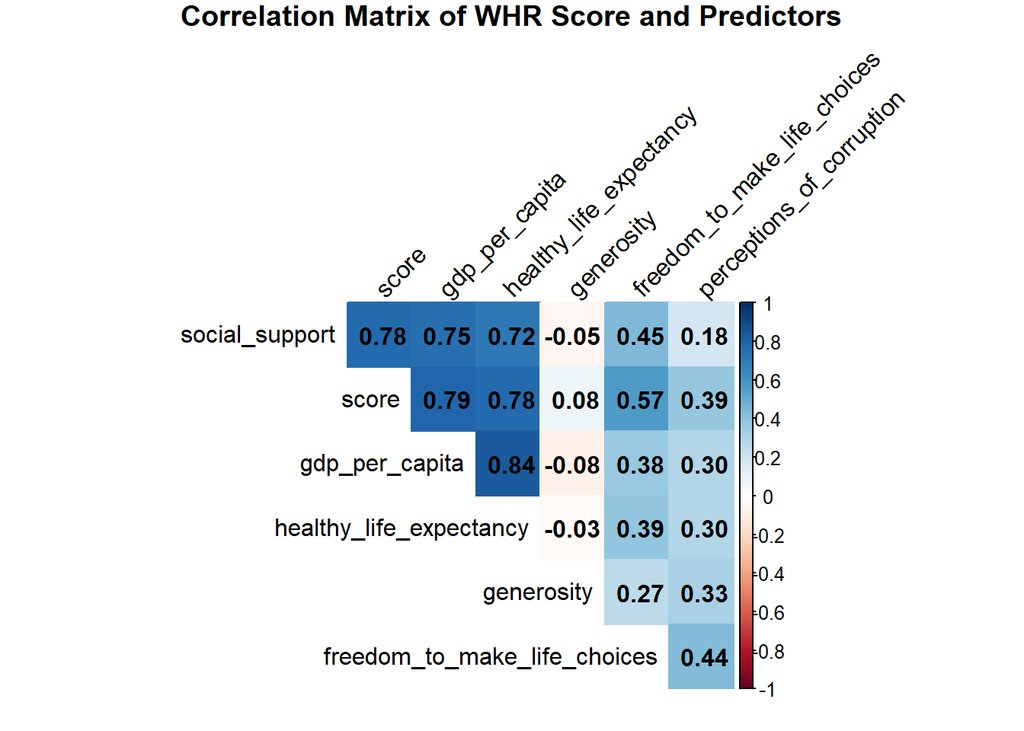

```r
# Visualize the correlation matrix - this command will display the plot
corrplot(correlation_matrix, method = "color", type = "upper", order = "hclust",
         addCoef.col = "black", # Add correlation coefficients
         tl.col = "black", tl.srt = 45, # Text label color and rotation
         diag = FALSE, # Don't plot correlation with self
         main = "Correlation Matrix of WHR Score and Predictors", mar=c(0,0,1,0))
```

```r
# Query: Find predictor with highest absolute correlation with score
cor_with_score <- correlation_matrix["score", -which(colnames(correlation_matrix) == "score")]
strongest_predictor <- names(which.max(abs(cor_with_score)))
max_cor <- max(abs(cor_with_score))

print(paste("Predictor with strongest absolute correlation with score:", strongest_predictor, "(Correlation:", round(max_cor, 3), ")"))
```

```
## [1] "Predictor with strongest absolute correlation with score: gdp_per_capita (Correlation: 0.794 )"
```

### Results

**Assessment**:

The heatmap visually shows a strong positive correlations between score and gdp_per_capita (r=0.794), healthy_life_expectancy (r=0.780), and social_support (r=0.777). freedom_to_make_life_choices has a moderate positive correlation (r=0.567). perceptions_of_corruption has a weaker positive correlation (r=0.386), and generosity has a very weak positive correlation (r=0.076). The query confirms gdp_per_capita has the highest simple linear correlation with the score. This provides a comprehensive view supporting Objective 1.

## Task 3:

### Background

Objective: Examine demographic variations in happiness/well-being (Objective 4), specifically focusing on the relationship between objective income levels (quintiles) and the Thriving Index within the global GWBI data.

Type: Data Visualization (Bar Plot).

### Code

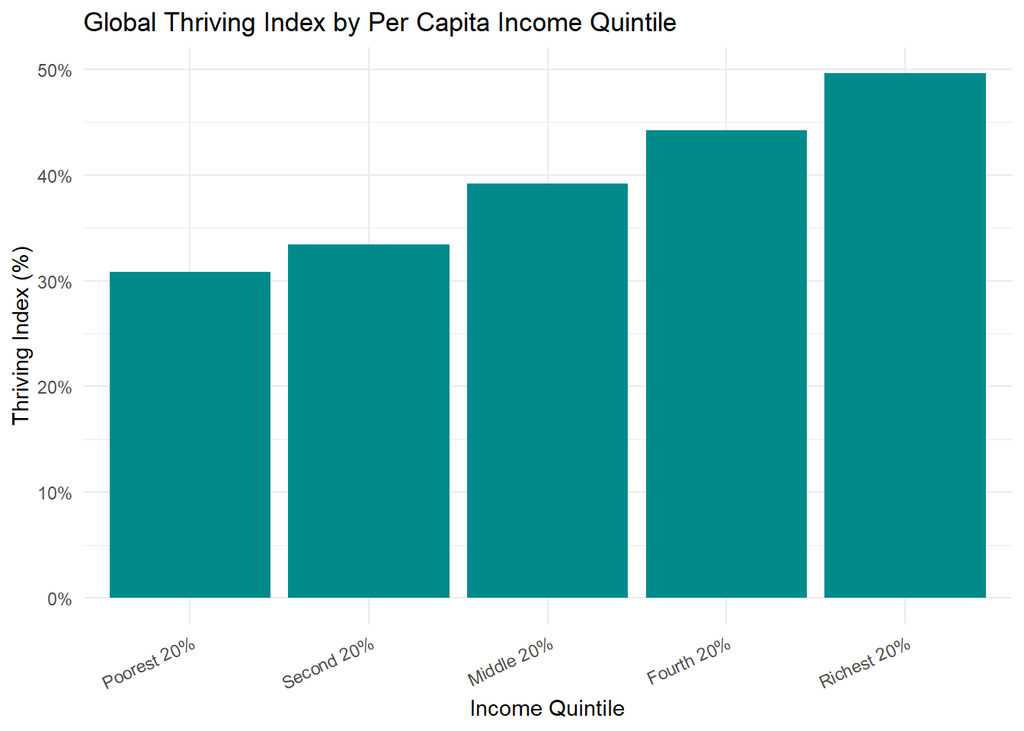

```
## [1] "Plot saved to viz_A04/task3_plot_quintile_thriving.png"
```

```r
# Task 3: GWBI Thriving Index by Income Quintile (Global)

# Ensure factor levels are ordered correctly for plotting
income_quintile_order <- c("Poorest 20%", "Second 20%", "Middle 20%", "Fourth 20%", "Richest 20%")

plot_quintile_thriving <- global_wellbeing_global_clean %>%
  filter(Demographic_Category == "Per Capita Income Quintiles") %>%
  mutate(Demographic_Value = factor(Demographic_Value, levels = income_quintile_order)) %>%
  # Check for data
  {
    if(nrow(.) == 0) {
      print("No data found for Demographic_Category == 'Per Capita Income Quintiles'. Check spelling/case.")
    } else {
       ggplot(., aes(x = Demographic_Value, y = Thriving_Index_Pct)) +
        geom_bar(stat = "identity", fill = "darkcyan") +
        scale_y_continuous(labels = scales::percent_format()) +
        labs(title = "Global Thriving Index by Per Capita Income Quintile",
             x = "Income Quintile",
             y = "Thriving Index (%)") +
        theme_minimal() +
        theme(axis.text.x = element_text(angle = 25, hjust = 1))
    }
  }


if (exists("plot_quintile_thriving") && !is.null(plot_quintile_thriving)) {
  print(plot_quintile_thriving)
  ggsave("viz_A04/task3_plot_quintile_thriving.png", plot_quintile_thriving, width = 7, height = 5)
  print("Plot saved to viz_A04/task3_plot_quintile_thriving.png")
}
```

```r
# DQ: Show the data table used for the plot
quintile_data_table <- global_wellbeing_global_clean %>%
   filter(Demographic_Category == "Per Capita Income Quintiles") %>%
   select(Demographic_Value, Thriving_Index_Pct) %>%
   mutate(Demographic_Value = factor(Demographic_Value, levels = income_quintile_order)) %>%
   arrange(Demographic_Value)

print("Data Table for Thriving Index by Income Quintile:")
```

```
## [1] "Data Table for Thriving Index by Income Quintile:"
```

```r
print(quintile_data_table)
```

```
## # A tibble: 5 × 2
##   Demographic_Value Thriving_Index_Pct
##   <fct>                          <dbl>
## 1 Poorest 20%                    0.308
## 2 Second 20%                     0.334
## 3 Middle 20%                     0.392
## 4 Fourth 20%                     0.442
## 5 Richest 20%                    0.496
```

### Results

**Assessment**:

The visualization demonstrates a strong positive relationship between income quintile and the Thriving Index globally. Each step up in income quintile has a noticeable increase in the percentage of people thriving. The difference between the poorest and richest 20% is significant (30.8% vs 49.6%). This provides further evidence, using a more objective income grouping, for the importance of economic factors in well-being (Objective 4).

**Comments/Remarks**:

This task complements Task 5 from Assignment 03. While subjective feelings about income showed a significant divide, the objective quintiles show a clearer, positive association between income and thriving.

# Conclusions

**Understand Loop** (Transform -> Visualize -> Model):